# Credit Card Brand Attribute Ratings

Mark Preston

December 2, 2018

### Introduction: Examining brand attribute ratings and consumer preferences

In this analysis, I’ll use consumer survey data collected on individual credit card company preferences. This brand strategy data provides a forum for consumers to provide feedback on how they feel about certain banking products. Overall, this analysis will work towards building models that establish a relationship between the brand attribute ratings consumers provided and their preference ratings for credit cards.

Before proceeding with the work, I’ll highlight data transformations which I performed. Most notably, the initial data set has unclear, non-descriptive column names. The columns are the primarily comprised of the brand attribute ratings so I felt it was essential to better label these. As such, I’ve provided more descriptive column names. Beyond this, I’ve changed the missing data values from -99 to 0 (after altering the zero values for the pri_sec column for consistency) and added the brand names for each credit card.

```r
library(tidyverse)
library(corrplot)
library(lavaan)
library(semPlot)
library(Metrics)
library(lme4)
library(car)
library(kableExtra)
library(knitr)

#setting ggplot preference
theme_set(
  theme_minimal()
)

#custom table function
custom_kable <- function(x){
  kable(x, format = "html") %>%
    kable_styling(bootstrap_options = "striped")
}

cc_brands <- read.csv("Brand_stratategy_data.csv") %>%
  rename(respondent = "ï..respid",
         revenue_group = hq_cell,
         brand = brandid,
         comp_pref = q6,
         preference_rating = consider,
         easy_access = att_rating1,
         channel_access = att_rating2,
         products_for_bus = att_rating3,
         bus_cash_flow = att_rating4,
         cool = att_rating5,
         emerging_leader = att_rating6,
         innovative = att_rating7,
         personalize_service = att_rating8,
         trustworthy = att_rating9,
         responsive_bus_needs = att_rating10,
         business_advisor = att_rating11,
         understand_bus_probs = att_rating12,
         solves_bus_probs = att_rating13,
         my_best_interests = att_rating14,
         prestige = att_rating15,
         feel_valued = att_rating16,
         dual_recognition = att_rating17,
         rewards_for_good = att_rating18,
         bus_rewards_program = att_rating19,
         easy_application = att_rating20,
         customer_service = att_rating21,
         easy_bus_finance = att_rating22,
         clear_comms = att_rating23,
         account_infosec = att_rating24,
         life_easier = att_rating25,
         easy_bus_invest = att_rating26,
         quick_app_approval = att_rating27,
         reasonable_fees = att_rating28,
         best_prod_rates = att_rating29,
         fair_treatment = att_rating30,
         good_value = att_rating31) %>%
  mutate(pri_sec = ifelse(pri_sec == 0 , 3, pri_sec)) %>%
  mutate_all(function(x) ifelse(x == -99, 0, x)) %>%
  mutate(brand = case_when(
    brand == 1 ~ "Advanta",
    brand == 2 ~ "Amex",
    brand == 3 ~ "BoA",
    brand == 4 ~ "Chase",
    brand == 5 ~ "Citibank",
    brand == 6 ~ "HSBC",
    brand == 7 ~ "Wells_Fargo",
    brand == 8 ~ "Other_prim",
    brand == 9 ~ "Other_sec"
  )
)
```

### Exploratory Data Anlaysis: Reviewing credit card preferences

```r
cc_brands %>%
  count(respondent) %>%
  head() %>%
  kable(format = "html", align = "l") %>%
  kable_styling(bootstrap_options = "striped")
```

| respondent | n |
| --- | --- |
| 1 | 9 |
| 3 | 9 |
| 4 | 9 |
| 5 | 9 |
| 6 | 9 |
| 7 | 9 |

As a data quality check, I also wanted to make sure every respondent had nine brand reviews. The logical output shows that there are no respondents without the required number. This means no further data cleaning needs to take place.

```r
cc_brands %>%
  count(respondent) %>%
  summarise(any_respondent_without_nine_reviews = any(n != 9)) %>%
  custom_kable()
```

| any_respondent_without_nine_reviews |
| --- |
| FALSE |

Getting into the cardholder details, I’ve developed a table with the primary card counts. the largest group is respondents indicating they use a primary card outside of the seven named brands. After this, Bank of America has the highest count. Advanta has the fewest respondents using it as a primary card with only two. These are the first indications of how different brands might be perceived by consumers. For example, I do not think Advanta will have especially high ratings given the low primary usage.

```r
cc_brands %>%
  filter(pri_sec == 1) %>%
  count(pri_sec, brand, sort = T) %>%
  kable(format = "html", align = "l") %>%
  kable_styling(bootstrap_options = "striped")
```

| pri_sec | brand | n |
| --- | --- | --- |
| 1 | Other_prim | 321 |
| 1 | BoA | 98 |
| 1 | Amex | 68 |
| 1 | Chase | 52 |
| 1 | Citibank | 50 |
| 1 | Wells_Fargo | 47 |
| 1 | HSBC | 23 |
| 1 | Advanta | 2 |

Building on the previous section, I also wanted to review missing data for each brand. The initial data set contains numerous missing values, which are present when a respondent doesn’t know the brand and cannot offer a brand rating. In essence, I think this becomes a proxy for brand awareness where a low number of missing values means more respondents have an opinion or direct association with the card. As seen, Advanta has the most missing values, which is in line with the previous section where it had the fewest primary users. Amex and Chase have the fewest, which seems intuitive given how large the brands are.

```r
cc_brands %>%
  select(3, 8:38) %>%
  group_by(brand) %>%
  gather(key = "variable", value = "value", -brand) %>%
  filter(value == 0) %>%
  count(value, sort = T) %>%
  custom_kable()
```

| brand | value | n |
| --- | --- | --- |
| Advanta | 0 | 17670 |
| HSBC | 0 | 11501 |
| Other_sec | 0 | 11191 |
| Other_prim | 0 | 10540 |
| Wells_Fargo | 0 | 9858 |
| Citibank | 0 | 7595 |
| BoA | 0 | 4991 |
| Chase | 0 | 3131 |
| Amex | 0 | 3100 |

Moving into the preference ratings, I’ve put together the average score for each brand. The highest mean score for a named brand is Amex while an unnamed secondary card- which could be more than one brand- is top here. The previous work seemed to indicate Advanta might have a low rating, which is confirmed here; it has the lowest average preference rating by about 2.7 points. The rating scale here is from 1 to 11 (and I’ve filtered out the unknown values, which are 12) so that means Advanta isn’t much above the lowest possible score.

```r
cc_brands %>%
  filter(preference_rating != 12) %>%
  group_by(brand) %>%
  summarise(avg_pref_rating = mean(preference_rating)) %>%
  arrange(desc(avg_pref_rating)) %>%
  custom_kable()
```

| brand | avg_pref_rating |
| --- | --- |
| Other_sec | 8.805215 |
| Amex | 7.187404 |
| Citibank | 6.843077 |
| BoA | 6.475684 |
| Chase | 6.254573 |
| Wells_Fargo | 5.221374 |
| HSBC | 4.789313 |
| Other_prim | 4.368664 |
| Advanta | 1.662614 |

As a final review before the modelling phase, I wanted to see the average brand rating given by respondents across each question and brand. Amex sticks out here again as a brand with high consumer ratings. For example, respondents gave the question about information security an average of about 2.5. On a scale with only 3 values, this means that respondents view the score at about medium-high on average. Chase and Bank of America also stick out as having all average scores over 1.5. Yet again, Advanta shows the poorest metrics of any card, this time with the lowest brand ratings. The crucial question moving forward is how these brand ratings are associated with the consumer preference ratings.

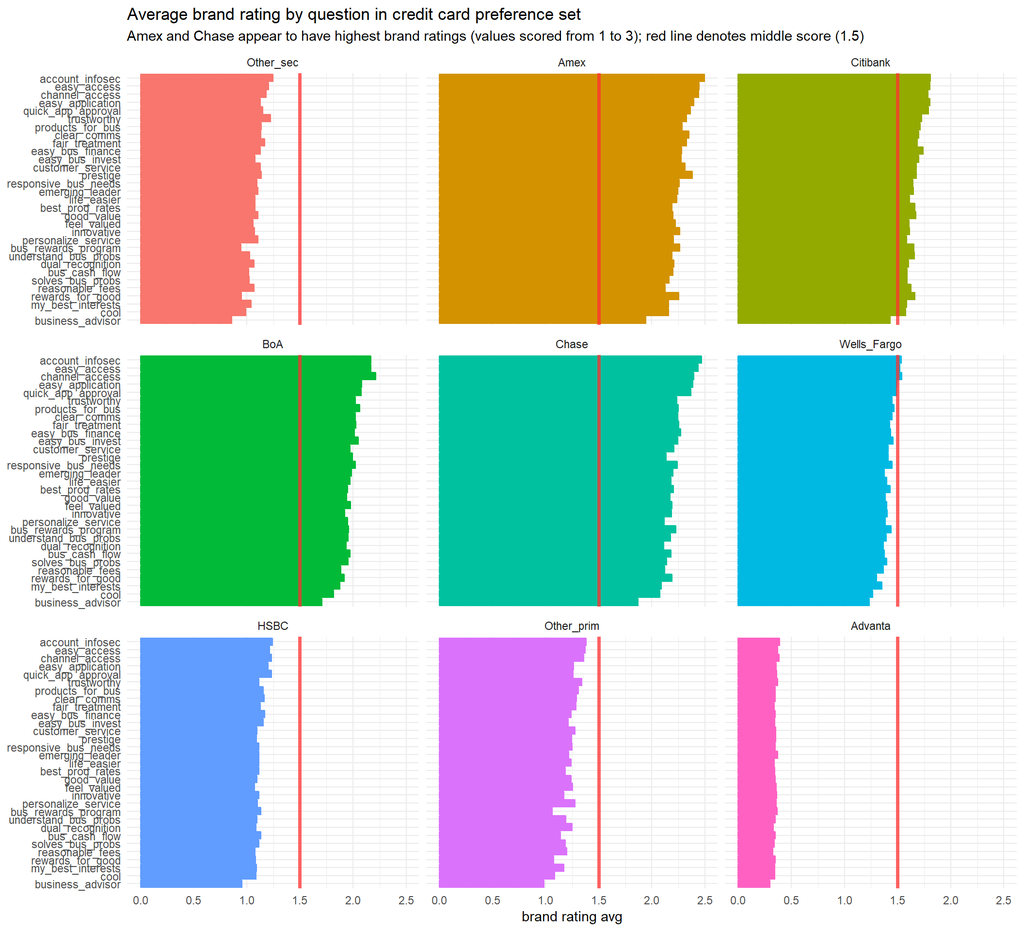

```r
cc_brands %>%
  select(3, 8:38) %>%
  group_by(brand) %>%
  summarise_if(is.numeric, function(x) mean(x)) %>%
  gather(key = "variable", value = "value", -brand) %>%
  mutate(brand = factor(brand, levels = c("Other_sec", "Amex", "Citibank", "BoA",
                                          "Chase", "Wells_Fargo", "HSBC",
                                          "Other_prim", "Advanta")),
         variable = reorder(variable, value)) %>%
  filter(value != 4) %>%
  ggplot(aes(variable, value, colour = brand, fill = brand)) +
  geom_col(show.legend = F) +
  geom_hline(yintercept = 1.5, colour = "firebrick1", size = 1.3, alpha = .75) +
  coord_flip() +
  facet_wrap(facets = "brand") +
  labs(title = "Average brand rating by question in credit card preference set",
       subtitle = "Amex and Chase appear to have highest brand ratings (values scored from 1 to 3); red line denotes middle score (1.5)",
       x = NULL,
       y = "brand rating avg")
```

### Linear model with brand ratings: Structural problems and multicollinearity

Additionally, the set has extremely high multicollinearity. The correlation plot below shows that each variable has very high correlation with almost every other variable. Again, this is largely because all the values are positive and closely aligned to begin with, which inherently introduces this structure. The introduction of multicollinearity inflates standard errors and therefore, will negatively impact any regression modelling.

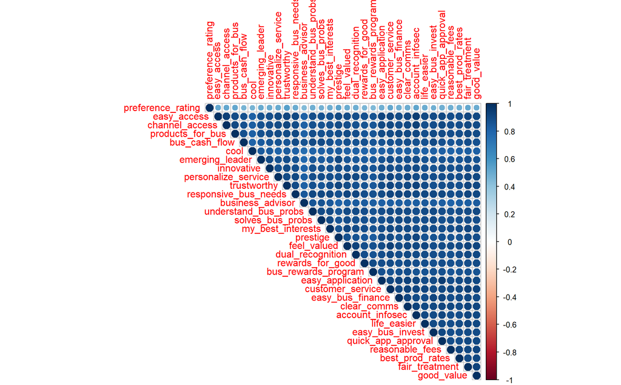

```r
cc_brands %>%
  select(7:38) %>%
  cor() %>%
  corrplot(type = "upper")
```

Just to highlight this, I’ve developed a linear model with all the brand ratings. The plot below shows the predictions are erratic and at times nowhere near correct. That said, there is a heavier concentration of points below 3, which indicates there are predictions that might be useable.

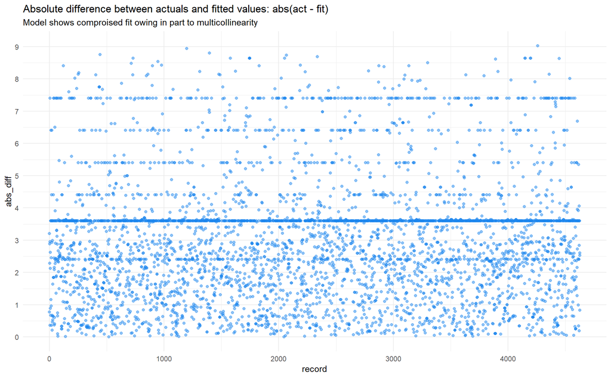

```r
profiles <- c(seq(1, nrow(cc_brands), 9), seq(5, nrow(cc_brands), 9)) %>%
  as.data.frame() %>%
  rename(holdout = ".") %>%
  arrange(holdout)

brand_train <- cc_brands %>%
  select(1, 7:38) %>%
  filter(!row_number() %in% profiles$holdout)

brand_test <- cc_brands %>%
  select(1, 7:38) %>%
  filter(row_number() %in% profiles$holdout)

brand_lm <- lm(preference_rating ~ ., data = brand_train[,-1])

data.frame(
  record = seq(1, nrow(brand_train), 1),
  fitted = brand_lm$fitted.values,
  actual = brand_train$preference_rating
) %>%
  mutate(abs_diff = abs(actual - fitted)) %>%
  ggplot(aes(record, abs_diff)) +
  geom_point(colour = "dodgerblue2", alpha = .5) +
  scale_y_continuous(breaks = seq(0, 10, 1)) +
  labs(title = "Absolute difference between actuals and fitted values: abs(act - fit)",
       subtitle = "Model shows comproised fit owing in part to multicollinearity")
```

Apart from the predictive component, the model summary also provides cause for concern. The slope coefficients and p-values are variable and do not show any intuitive pattern for why a feature might be positive or negative. Again, this is the product of multicollinearity. Overall, I do not think this approach yields a reasonable solution

```r
summary(brand_lm)
```

```
##
## Call:
## lm(formula = preference_rating ~ ., data = brand_train[, -1])
##
## Residuals:
##     Min      1Q  Median      3Q     Max
## -9.0221 -3.5958  0.3373  2.4929  8.4042
##
## Coefficients:
##                       Estimate Std. Error t value Pr(>|t|)
## (Intercept)           3.595780   0.082822  43.416  < 2e-16 ***
## easy_access           0.042349   0.122921   0.345 0.730468
## channel_access        0.088080   0.117540   0.749 0.453677
## products_for_bus      0.296972   0.106102   2.799 0.005148 **
## bus_cash_flow        -0.094974   0.098050  -0.969 0.332783
## cool                 -0.017215   0.072076  -0.239 0.811241
## emerging_leader       0.171434   0.098669   1.737 0.082372 .
## innovative           -0.070734   0.101860  -0.694 0.487451
## personalize_service   0.255275   0.110206   2.316 0.020584 *
## trustworthy           0.800566   0.119563   6.696 2.40e-11 ***
## responsive_bus_needs  0.017213   0.117720   0.146 0.883751
## business_advisor     -0.172516   0.083759  -2.060 0.039485 *
## understand_bus_probs  0.054343   0.106541   0.510 0.610033
## solves_bus_probs      0.050606   0.103788   0.488 0.625861
## my_best_interests     0.106545   0.109112   0.976 0.328883
## prestige              0.482980   0.111544   4.330 1.52e-05 ***
## feel_valued          -0.033155   0.122586  -0.270 0.786813
## dual_recognition     -0.009135   0.108902  -0.084 0.933157
## rewards_for_good     -0.320123   0.100747  -3.177 0.001495 **
## bus_rewards_program  -0.343779   0.089856  -3.826 0.000132 ***
## easy_application     -0.303879   0.121223  -2.507 0.012218 *
## customer_service      0.205830   0.129277   1.592 0.111416
## easy_bus_finance     -0.113435   0.107220  -1.058 0.290127
## clear_comms          -0.170823   0.125118  -1.365 0.172226
## account_infosec       0.278226   0.129749   2.144 0.032058 *
## life_easier           0.032543   0.109668   0.297 0.766676
## easy_bus_invest       0.027773   0.106746   0.260 0.794738
## quick_app_approval   -0.018726   0.121261  -0.154 0.877279
## reasonable_fees       0.035168   0.108203   0.325 0.745182
## best_prod_rates      -0.079534   0.103907  -0.765 0.444053
## fair_treatment        0.322699   0.127432   2.532 0.011364 *
## good_value           -0.010108   0.121896  -0.083 0.933917
## ---
## Signif. codes:  0 '***' 0.001 '**' 0.01 '*' 0.05 '.' 0.1 ' ' 1
##
## Residual standard error: 3.582 on 4595 degrees of freedom
## Multiple R-squared:  0.2877, Adjusted R-squared:  0.2828
## F-statistic: 59.86 on 31 and 4595 DF,  p-value: < 2.2e-16
```

To formalize how impactuful the multicollinearity is, I’ve included a variance inflation factor (VIF) chart for the model. These values provide an estimate for how much the regression coefficients are inflated. As a rule of thumb, a VIF greater than 4 signals high multicollinearity while values over 10 highlight extreme levels. As seen below, the lowest value is above four and numerous variables are above 10. This means some corrections need to take place so any modelling result can be interpretable.

```r
vif(mod = brand_lm) %>%
  as.data.frame() %>%
  rownames_to_column(var = "variable") %>%
  rename(vif = ".") %>%
  arrange(desc(vif)) %>%
  custom_kable()
```

| variable | vif |
| --- | --- |
| account_infosec | 13.908085 |
| customer_service | 12.806777 |
| fair_treatment | 12.779284 |
| easy_access | 12.498585 |
| clear_comms | 12.396887 |
| quick_app_approval | 12.252977 |
| easy_application | 12.186129 |
| feel_valued | 11.652311 |
| channel_access | 11.328081 |
| good_value | 11.080077 |
| responsive_bus_needs | 10.952055 |
| trustworthy | 10.750142 |
| easy_bus_finance | 9.396998 |
| easy_bus_invest | 9.335728 |
| life_easier | 9.269039 |
| dual_recognition | 9.192325 |
| personalize_service | 9.113532 |
| prestige | 8.978703 |
| my_best_interests | 8.928914 |
| products_for_bus | 8.896782 |
| reasonable_fees | 8.702255 |
| understand_bus_probs | 8.701236 |
| solves_bus_probs | 8.486546 |
| best_prod_rates | 8.448113 |
| rewards_for_good | 7.818170 |
| innovative | 7.739050 |
| bus_cash_flow | 7.583036 |
| emerging_leader | 7.329460 |
| bus_rewards_program | 6.640017 |
| business_advisor | 4.861969 |
| cool | 4.048980 |

### PCA regression and factor analysis with brand data

To effectively deal with the set’s multicollinearity, principle components analysis (PCA) is a reasonable solution. The method orthogonalizes the input data resulting in predictors that are uncorrelated. Additionally, the information from numerous columns can be compacted into fewer variables so there are fewer variables to work with (dimensional reduction). To begin this process, I’ve conducted PCA on the predictors here. As a note, I elected not to transform the variables since they are all on the same rating scale.

Selecting the correct number of factors here can be accomplished using a scree plot. The visualization shows a definite break at seven components. That said, the first principle component captures 89% of the variance with only 1% increases thereafter. As such, I think taking seven is too many as PCA2 to PCA7 only capture 6% of the variance. I’m going to carry forward the first three, which still captures a very high 91% of variance. As always, in a business setting this approach would need to be verified with the brand manager to ensure this was reasonable.

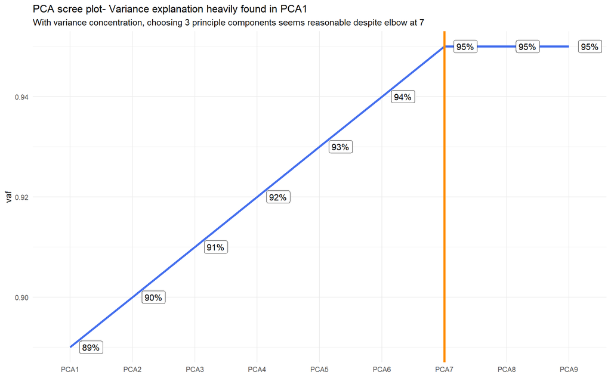

```r
brand_pca <- princomp(x = cc_brands[,8:38])

data.frame(dev = brand_pca$sdev ^ 2) %>%
  rownames_to_column(var = "PC") %>%
  mutate(variance_exp = round(dev / (sum(dev)), 2),
         vaf = cumsum(variance_exp),
         PC = str_replace(string = PC, pattern = "Comp.", replacement = "PCA"),
         vaf_line = "line") %>%
  slice(1:9) %>%
  ggplot(aes(PC, vaf, group = vaf_line, label = paste0(vaf * 100,"%"))) +
  geom_line(colour = "royalblue2", size = 1.3) +
  geom_label(hjust = 0, nudge_x = 0.15, nudge_y = 0) +
  geom_vline(xintercept = 7, size = 1.3, colour = "darkorange") +
  labs(title = "PCA scree plot- Variance explanation heavily found in PCA1",
       subtitle = "With variance concentration, choosing 3 principle components seems reasonable despite elbow at 7",
       x = NULL)
```

As part of the PCA, I’ll also review the component loadings for each variable. This provides insight into what information is captured in each principle component. To do so, I’ve developed a faceted bar chart for each component. Overall, the factors do lend enough variability so each can be named and interpreted. These can be found below:

#### Factor interpretation and naming

##### - PCA1 attributes: Uniformly negative scores

##### - Name: Steady Dislike

##### - PCA2 attributes: Highest positive scores for trustworthy, prestige, emerging leader, easy access, and cool

##### - Name: Brand Perception

##### - PCA3 attributes: Highest positive scores for service and product related features (clear comms, customer service, easy application, etc.). Additionally, low on brand perception valus

##### - Name: Product and Features Utility

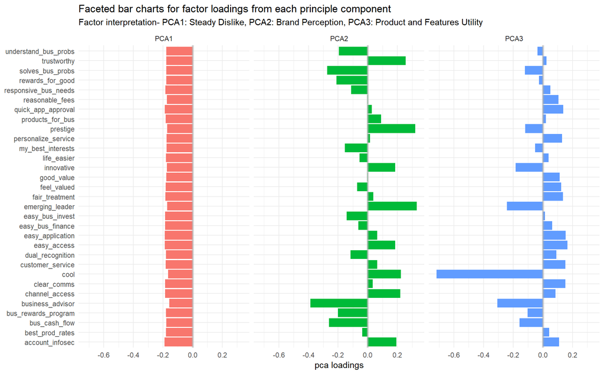

```r
as.data.frame(brand_pca$loadings[,1:3]) %>%
  rownames_to_column(var = "variable") %>%
  rename_all(function(x) gsub(pattern = "Comp.",
                              replacement = "PCA",
                              x = x)) %>%
  gather(key = "pca", value = "pca_loadings", -variable) %>%
  ggplot(aes(variable, pca_loadings, fill = pca)) +
  geom_col(show.legend = F) +
  facet_wrap(facets = "pca", nrow = 1) +
  geom_hline(yintercept = 0, alpha = .5, size = 1.3, colour = "darkgray") +
  scale_y_continuous(breaks = seq(-1, 1, .2)) +
  coord_flip() +
  labs(title = "Faceted bar charts for factor loadings from each principle component",
       subtitle = "Factor interpretation- PCA1: Steady Dislike, PCA2: Brand Perception, PCA3: Product and Features Utility",
       y = "pca loadings",
       x = NULL)
```

With the new components named, I’ve put together a train and test split with the factor scores so a linear model can be developed. These are used the same way the initial predictors are so I’ve also added the preferences ratings back in so the model can be cast using one data set.

The summary shows significant coefficients for all three variables, though the product utility is a matter of interpretation. The strength of evidence is right at the normal .05 alpha level but, I’m giving it a pass because it adds further inferential interpretability to the model.

The slope coefficients are far more interpretable here owing to the transformation and seem intuitive. Both brand perception and product utility are associated with higher preference ratings while the steady dislike feature is negative. Between brand and product utility, the perception component has a higher slope coefficient as well. The model’s R2 is about .265, which is a slight drop from the initial linear attempt (.283).

```r
brand_factors <- brand_pca$scores %>%
  as.data.frame() %>%
  select(1:3) %>%
  rename(Steady_Dislike = "Comp.1",
         Brand_Perception = "Comp.2",
         Product_Utility = "Comp.3") %>%
  mutate(preference_rating = cc_brands$preference_rating,
         respondent = cc_brands$respondent)

pca_train <- brand_factors %>%
  filter(!row_number() %in% profiles$holdout)

pca_test <- brand_factors %>%
  filter(row_number() %in% profiles$holdout)

brand_pca_lm <- lm(preference_rating ~ Steady_Dislike +
                     Brand_Perception +
                     Product_Utility,
                   data = pca_train)

summary(brand_pca_lm)
```

```
##
## Call:
## lm(formula = preference_rating ~ Steady_Dislike + Brand_Perception +
##     Product_Utility, data = pca_train)
##
## Residuals:
##     Min      1Q  Median      3Q     Max
## -9.3193 -3.6202  0.3283  2.7325  8.3798
##
## Coefficients:
##                   Estimate Std. Error t value Pr(>|t|)
## (Intercept)       5.998260   0.053584 111.941   <2e-16 ***
## Steady_Dislike   -0.271829   0.006962 -39.047   <2e-16 ***
## Brand_Perception  0.707103   0.056477  12.520   <2e-16 ***
## Product_Utility   0.123872   0.064487   1.921   0.0548 .
## ---
## Signif. codes:  0 '***' 0.001 '**' 0.01 '*' 0.05 '.' 0.1 ' ' 1
##
## Residual standard error: 3.626 on 4623 degrees of freedom
## Multiple R-squared:  0.2655, Adjusted R-squared:  0.2651
## F-statistic: 557.1 on 3 and 4623 DF,  p-value: < 2.2e-16
```

While the pca regression helps with coefficient interpretation, it does not enhance the model’s predictive capabilities. This is because the predictors are only being compressed and represented in a different mathematical form, which means no new information is added. In fact, the pca model has slightly less variance being explained.

Reviewing the mean absolute error (MAE) for both the train and test still shows debatable predictive powers. The test MAE is about 3.26, which means each prediction is off by that many points (on average). The initial preference ratings only have an 11 point scale so this isn’t great. For example, a perfect 11 might be predicted at 7.8, a value which tells a different customer brand preference story.

That said, this accuracy threshold would be best reviewed with the business for utility. If the values are broadly accurate for a consumer, the prediction might have marketing power. Overall though, I still think the pca model was more useful for getting a better understanding of the relationship between brand attribute ratings and preferences, rather than prediction. Here, the inferential component far outweighs the forward looking aspect.

```r
data.frame(
  model = c("train", "test"),
  mae = c(
    mae(actual = pca_train$preference_rating,
        predicted = brand_pca_lm$fitted.values),
    mae(actual = pca_test$preference_rating,
        predicted = predict(brand_pca_lm, pca_test))
  )
) %>% custom_kable()
```

| model | mae |
| --- | --- |
| train | 3.127171 |
| test | 3.262093 |

In an attempt to get better predictive results, I also developed a linear mixed effects model with the pca data. The addition of random effects for each respondent introduces individual coefficients alongside the group fixed effects. The new method introduces some prediction gains, though the increase from about 3.2 to 3 MAE is modest.

```r
brand_mixed <- lmer(preference_rating ~ Steady_Dislike +
                      Brand_Perception +
                      Product_Utility +
                      (1 + Steady_Dislike +
                         Brand_Perception +
                         Product_Utility | respondent),
                    data = pca_train)

data.frame(
  model = c("train", "test"),
  mae = c(
    mae(actual = pca_train$preference_rating,
        predicted = predict(brand_mixed, pca_train)),
    mae(actual = pca_test$preference_rating,
        predicted = predict(brand_mixed, pca_test))
  )
) %>% custom_kable()
```

| model | mae |
| --- | --- |
| train | 2.660446 |
| test | 3.000280 |

### Confirmatory Structural Equation Modelling

The other very real product of beginning with the inferential statistical modelling was developing a general hypothesis for how brand attribute ratings might be connected with preferences. This theory can be tested further using structural equation modelling (SEM), which is used to theorize causal relationships and the general pathways between measured and latent variables. The technique is confirmatory, meaning it can be used to advance a theory that’s been developed using some subject matter expertise. Here, I’ll be using the initial empirical result to further formulate how brand ratings and preference might be linked.

The modelling set up here differs from a more traditional statistical approach in R. SEM requires developing exogenous, endogenous, and latent variables. Exogenous variables do not have any causal elements represented and stand as the origin in the model. For the model I’ll develop, my basic hypothesis is that preference rating (here a latent exogenous variable) is an amalgamation of several contributing latent factors.

This hypothesis stems from the factor analysis. Factor one showed a general brand and product dislike while factor two and three highlighted brand perceptions and product utility. Unfortunately, the first principle component does not seem to provide any wider marketing interpretation but, the others represent ideas which can be formalized as latent variables in the SEM.

However, I wanted to further refine the initial factors from the pca as well. For this, I theorized that the product utility could be divided into general service features (channel access) and business services (easy business financing). In the same vein, I retained brand perception as a factor but, also included a latent variable for product attitudes, which are more finite than a broad brand sentiment. These four latent variables, also called factors, form the basis of the measurement model and are linked to known brand attribute ratings.

Putting this together yields a three level SEM with five latent variables. The SEM paths are visualized below. As seen, brand preference (denoted as PR for preference) is informed by service features, brand perceptions, product attributes, and business services. In turn, these are linked to the predictors from the survey. Circles denote the latent variables while squares are measured endogenous variables.

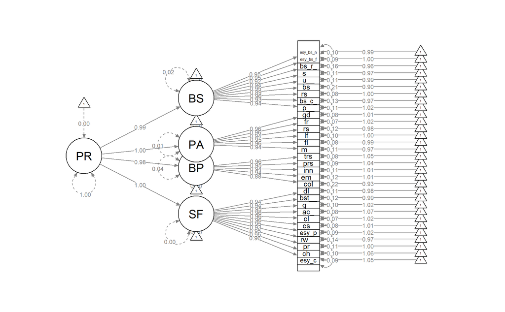

```r
brand_model <- "
#Service Features
SF =~ easy_access + channel_access + personalize_service +
  rewards_for_good + easy_application + customer_service + clear_comms + account_infosec + quick_app_approval + best_prod_rates + dual_recognition

#Brand Perceptions
BP =~ cool + emerging_leader + innovative + prestige + trustworthy

#Product Attitudes
PA =~ my_best_interests + feel_valued + life_easier + reasonable_fees +
  fair_treatment + good_value

#Business Services
BS =~ products_for_bus + bus_cash_flow + responsive_bus_needs +
  business_advisor + understand_bus_probs + solves_bus_probs + bus_rewards_program +
  easy_bus_finance + easy_bus_invest

#Overall latent arrangement for Preference Rating (PR)
PR =~ SF + BS + BP + PA
"

brand_sem <- sem(model = brand_model,
                 data = cc_brands,
                 meanstructure = T,
                 std.lv = T)

semPaths(object = brand_sem, whatLabels = "std", rotation = 2)
```

With the model estimated, it’s essential to work through the SEM parameters to ascertain what insights can be revealed about the relationship between the latent and measured variables. Broadly speaking, I’m trying to better understand the confirmatory properties of the model with a focus on how brand ratings are linked to credit card preferences.

I’ve developed a helpful summary function for the model parameter estimates, `sem_param_review`, which I’m using below. The function filters all the model parameters related to one of the latent regressions (~= indicates “is measured by”) (Hartman, 2017). This extracts the factor loadings for each latent variable, which are akin to the regression coefficients.

The first table for service features shows positive coefficients (est column) for all the included endogenous variables ranging from .074 to .069. This seems to indicate all the included measured variables have a positive effect on the latent factor. Account information security seems to have the largest effect but, is only marginally larger than many other variables.

```r
sem_param_review <- function(model, latent_var){
  parameterestimates(object = model) %>%
  filter(op == "=~" & lhs == latent_var) %>%
  arrange(desc(est)) %>%
  custom_kable()
}

sem_param_review(model = brand_sem, latent_var = "SF")
```

| lhs | op | rhs | est | se | z | pvalue | ci.lower | ci.upper |
| --- | --- | --- | --- | --- | --- | --- | --- | --- |
| SF | =~ | account_infosec | 0.0741026 | 0.0070386 | 10.52802 | 0 | 0.0603072 | 0.0878980 |
| SF | =~ | easy_access | 0.0737925 | 0.0070096 | 10.52735 | 0 | 0.0600539 | 0.0875310 |
| SF | =~ | quick_app_approval | 0.0735629 | 0.0069885 | 10.52622 | 0 | 0.0598656 | 0.0872601 |
| SF | =~ | easy_application | 0.0735545 | 0.0069874 | 10.52669 | 0 | 0.0598594 | 0.0872496 |
| SF | =~ | channel_access | 0.0729391 | 0.0069295 | 10.52581 | 0 | 0.0593575 | 0.0865208 |
| SF | =~ | clear_comms | 0.0724691 | 0.0068830 | 10.52874 | 0 | 0.0589787 | 0.0859595 |
| SF | =~ | customer_service | 0.0712271 | 0.0067652 | 10.52839 | 0 | 0.0579675 | 0.0844868 |
| SF | =~ | best_prod_rates | 0.0700994 | 0.0066613 | 10.52339 | 0 | 0.0570435 | 0.0831553 |
| SF | =~ | dual_recognition | 0.0698399 | 0.0066362 | 10.52402 | 0 | 0.0568331 | 0.0828467 |
| SF | =~ | personalize_service | 0.0691558 | 0.0065706 | 10.52511 | 0 | 0.0562778 | 0.0820338 |
| SF | =~ | rewards_for_good | 0.0688778 | 0.0065466 | 10.52114 | 0 | 0.0560467 | 0.0817089 |

For brand perception, the coefficient estimates are similarly positive and close in value with trustworthy being the highest value. Cool is the lowest estimate, which is slightly surprising, although the values are very close in value so it might be more noise anything.

```r
sem_param_review(model = brand_sem, latent_var = "BP")
```

| lhs | op | rhs | est | se | z | pvalue | ci.lower | ci.upper |
| --- | --- | --- | --- | --- | --- | --- | --- | --- |
| BP | =~ | trustworthy | 0.2771749 | 0.0048071 | 57.65896 | 0 | 0.2677530 | 0.2865967 |
| BP | =~ | emerging_leader | 0.2703813 | 0.0047489 | 56.93532 | 0 | 0.2610736 | 0.2796890 |
| BP | =~ | innovative | 0.2701876 | 0.0047291 | 57.13259 | 0 | 0.2609186 | 0.2794565 |
| BP | =~ | prestige | 0.2692434 | 0.0046849 | 57.47041 | 0 | 0.2600611 | 0.2784256 |
| BP | =~ | cool | 0.2569425 | 0.0046931 | 54.74889 | 0 | 0.2477442 | 0.2661408 |

The product attitude table again shows very homogeneous estimate coefficients with fair treatment as the highest.

```r
sem_param_review(model = brand_sem, latent_var = "PA")
```

| lhs | op | rhs | est | se | z | pvalue | ci.lower | ci.upper |
| --- | --- | --- | --- | --- | --- | --- | --- | --- |
| PA | =~ | fair_treatment | 0.1365889 | 0.0050080 | 27.27437 | 0 | 0.1267735 | 0.1464043 |
| PA | =~ | feel_valued | 0.1343629 | 0.0049307 | 27.25038 | 0 | 0.1246989 | 0.1440268 |
| PA | =~ | life_easier | 0.1329972 | 0.0048851 | 27.22527 | 0 | 0.1234226 | 0.1425717 |
| PA | =~ | good_value | 0.1325288 | 0.0048623 | 27.25632 | 0 | 0.1229989 | 0.1420588 |
| PA | =~ | my_best_interests | 0.1302609 | 0.0047891 | 27.19947 | 0 | 0.1208745 | 0.1396474 |
| PA | =~ | reasonable_fees | 0.1293977 | 0.0047596 | 27.18673 | 0 | 0.1200691 | 0.1387263 |

Estimates for the business services deviate from the other latent factors owing to a wider range of coefficients. Easy business financing has the largest positive effect while having the card company act as a business advisor is the lowest. As with the previous latent factors, all variables show significance with p-values under .05.

```r
sem_param_review(model = brand_sem, latent_var = "BS")
```

| lhs | op | rhs | est | se | z | pvalue | ci.lower | ci.upper |
| --- | --- | --- | --- | --- | --- | --- | --- | --- |
| BS | =~ | easy_bus_finance | 0.2048070 | 0.0040730 | 50.28430 | 0 | 0.1968241 | 0.2127899 |
| BS | =~ | easy_bus_invest | 0.2046128 | 0.0040714 | 50.25606 | 0 | 0.1966330 | 0.2125926 |
| BS | =~ | responsive_bus_needs | 0.2023908 | 0.0040103 | 50.46758 | 0 | 0.1945307 | 0.2102509 |
| BS | =~ | products_for_bus | 0.1998743 | 0.0039894 | 50.10079 | 0 | 0.1920552 | 0.2076935 |
| BS | =~ | solves_bus_probs | 0.1977592 | 0.0039521 | 50.03948 | 0 | 0.1900133 | 0.2055051 |
| BS | =~ | bus_rewards_program | 0.1975625 | 0.0039943 | 49.46050 | 0 | 0.1897337 | 0.2053913 |
| BS | =~ | understand_bus_probs | 0.1971947 | 0.0039318 | 50.15361 | 0 | 0.1894885 | 0.2049009 |
| BS | =~ | bus_cash_flow | 0.1966377 | 0.0039445 | 49.85111 | 0 | 0.1889066 | 0.2043688 |
| BS | =~ | business_advisor | 0.1743641 | 0.0035889 | 48.58412 | 0 | 0.1673300 | 0.1813983 |

For the final parameter estimate review, it appears that service features have the strongest effect on preferences. In contrast to the individual level latent factors, the estimates have a wider range. Despite all having significant p-values, service features are still about 15 points higher than brand perception. I think this indicates that consumer preference is driven by strong service options and product attitudes. It’s also worth noting that the endogenous variables included for product attitudes were more practical, service style indicators so I think this reinforces that point. These are the first insights into how the various latent variables, derived from the measurement model, affects overall consumer preference but, a clearer association is being developed.

```r
sem_param_review(model = brand_sem, latent_var = "PR")
```

| lhs | op | rhs | est | se | z | pvalue | ci.lower | ci.upper |
| --- | --- | --- | --- | --- | --- | --- | --- | --- |
| PR | =~ | SF | 19.831020 | 1.8949372 | 10.46526 | 0 | 16.117011 | 23.545028 |
| PR | =~ | PA | 10.455526 | 0.3958073 | 26.41569 | 0 | 9.679757 | 11.231294 |
| PR | =~ | BS | 6.983815 | 0.1522600 | 45.86771 | 0 | 6.685391 | 7.282239 |
| PR | =~ | BP | 4.954054 | 0.0976792 | 50.71757 | 0 | 4.762607 | 5.145502 |

Outside of the parameter estimates, it’s also important to examine the model residuals. In structural equation modelling, this means reviewing. The `residuals` function returns a correlation matrix for all the measured variables. Since the model suggests the expected relationship amongst variables, reviewing the results and comparing them to the actual values forms the residuals (ibid). The idea is that if there is a noticeable difference between the expected and actual correlations (around .1 or higher), there may be model fit issues.

Below, I’ve used `apply` in conjunction with `max` to find the largest residuals. Here, rewards for being a good customer and the business rewards program show the largest correlation indicating there might be something between these two variables not captured by the model. What’s interesting is these capture a similar marketing idea but, are represented under two separate latent factors owing to the personal versus business split. Similarly, the next two for easy and quick applications are also related variables, though these fall under the same factor. Overall though, the residuals appear reasonable, which is a first indication that there might be a good model fit.

```r
residuals(brand_sem, type = "cor")$cov %>%
  apply(., 2, max) %>%
  as.data.frame() %>%
  rownames_to_column(var = "variable") %>%
  rename(residual_cor = ".") %>%
  arrange(desc(residual_cor)) %>%
  slice(1:6) %>%
  custom_kable()
```

| variable | residual_cor |
| --- | --- |
| rewards_for_good | 0.0547735 |
| bus_rewards_program | 0.0547735 |
| easy_application | 0.0400734 |
| quick_app_approval | 0.0400734 |
| best_prod_rates | 0.0351433 |
| reasonable_fees | 0.0351433 |

To further confirm the model fit, I’ve developed a table with three commonly cited fit metrics. Starting with the first value, Comparative Fit Index (CFI) is used to measure if the model fits the data better than a baseline null model. The target values here are being greater than .9. As seen, the CFI value is .966, which notes a good fit.

Root mean square error of approximation (RMSEA) evaluates the approximation error for residuals. Essentially, this helps measure how closely the model patterns resemble the data. The baseline target is less than .08 which is observed here.

The final value is the chi-squared p-value, which also assesses overall model fit by discrepancy between the sample and fitted covariance matrices (Cornell, 2018). The p-value is well below a .05 alpha but, with a sample size this large, the test should inherently be small. I think the first two metrics are likely more relevant in this case. These metrics all indicate that the model shows good fit.

```r
fitMeasures(object = brand_sem,
            fit.measures = c("cfi", "rmsea", "pvalue")) %>%
  as.data.frame() %>%
  rownames_to_column(var = "fit_measure") %>%
  rename(value = ".") %>%
  mutate(value = round(value, 3)) %>%
  custom_kable()
```

| fit_measure | value |
| --- | --- |
| cfi | 0.966 |
| rmsea | 0.071 |
| pvalue | 0.000 |

As a final model check, the `lavaan` package has a function for reviewing possible improvements for SEMs. Most of the table shows places where extra covariances between variables should be added (as denoted by the ~~ operator). For example, one modification suggestion is adding a further covariance term for easy application and quick application approval. I’m largely ignoring these because most of these fall under the same latent variable to begin with.

However, three modifications do appeal to me here. The table shows adding customer service, best product rates, and dual recognition (i.e. recognizing a person and a business) to product attitudes. As a rule of thumb, the model is developed using some theory ahead of time, which suggests that these modifications might be viewed with a critical eye. That said, I think the suggestions surrounding product attitudes make sense in a marketing context and that the variables could reasonably be compiled under attitudes factor. A consumer could easily view custom service, the best rates, or dual recognition as attitudes.

```r
modificationindices(object = brand_sem, sort. = T) %>%
  as.data.frame() %>%
  slice (1:15) %>%
  custom_kable()
```

| lhs | op | rhs | mi | epc | sepc.lv | sepc.all | sepc.nox |
| --- | --- | --- | --- | --- | --- | --- | --- |
| easy_application | ~~ | quick_app_approval | 1239.0443 | 0.1073539 | 0.1073539 | 0.4868643 | 0.4868643 |
| easy_access | ~~ | channel_access | 690.1263 | 0.0785333 | 0.0785333 | 0.3638657 | 0.3638657 |
| easy_access | ~~ | account_infosec | 615.6647 | 0.0674373 | 0.0674373 | 0.3470880 | 0.3470880 |
| rewards_for_good | ~~ | bus_rewards_program | 585.9339 | 0.1070725 | 0.1070725 | 0.3282464 | 0.3282464 |
| best_prod_rates | ~~ | reasonable_fees | 451.5636 | 0.0738030 | 0.0738030 | 0.2915202 | 0.2915202 |
| channel_access | ~~ | account_infosec | 439.4871 | 0.0606359 | 0.0606359 | 0.2913823 | 0.2913823 |
| dual_recognition | ~~ | feel_valued | 392.5647 | 0.0591087 | 0.0591087 | 0.2764357 | 0.2764357 |
| BP | =~ | products_for_bus | 383.7304 | 0.1415206 | 0.7152414 | 0.4787623 | 0.4787623 |
| PA | =~ | customer_service | 317.1421 | 0.1618694 | 1.7001528 | 1.1554078 | 1.1554078 |
| PA | =~ | best_prod_rates | 314.1757 | 0.1964867 | 2.0637468 | 1.3913180 | 1.3913180 |
| PA | =~ | channel_access | 294.7498 | -0.1806741 | -1.8976629 | -1.2435415 | -1.2435415 |
| PR | =~ | best_prod_rates | 291.7358 | 7.4520416 | 7.4520416 | 5.0239494 | 5.0239494 |
| PA | =~ | dual_recognition | 283.3222 | 0.1818248 | 1.9097488 | 1.2960335 | 1.2960335 |
| bus_cash_flow | ~~ | business_advisor | 277.6533 | 0.0777729 | 0.0777729 | 0.2283240 | 0.2283240 |
| BP | =~ | account_infosec | 257.5518 | 0.1228894 | 0.6210799 | 0.4049461 | 0.4049461 |

As such, I’ll develop the new SEM with the three changes and evaluate the fit impact. All the metrics improve relative to the first model which is an encouraging sign.

```r
mod_brand_model <- "
#Service Features
SF =~ easy_access + channel_access + personalize_service +
  rewards_for_good + easy_application + clear_comms + account_infosec + quick_app_approval

#Brand Perceptions
BP =~ cool + emerging_leader + innovative + prestige + trustworthy

#Product Attitudes
PA =~ my_best_interests + feel_valued + life_easier + reasonable_fees +
  fair_treatment + good_value + dual_recognition + best_prod_rates + customer_service

#Business Services
BS =~ products_for_bus + bus_cash_flow + responsive_bus_needs +
  business_advisor + understand_bus_probs + solves_bus_probs + bus_rewards_program +
  easy_bus_finance + easy_bus_invest

#Overall latent arrangement for Preference Rating (PR)
PR =~ SF + BS + BP + PA
"

modified_brand_sem <- sem(model = mod_brand_model,
                          data = cc_brands,
                          meanstructure = T,
                          std.lv = T)

fitMeasures(object = modified_brand_sem,
            fit.measures = c("cfi", "rmsea", "pvalue")) %>%
  as.data.frame() %>%
  rownames_to_column(var = "fit_measure") %>%
  rename(value = ".") %>%
  mutate(value = round(value, 3)) %>%
  custom_kable()
```

| fit_measure | value |
| --- | --- |
| cfi | 0.969 |
| rmsea | 0.069 |
| pvalue | 0.000 |

Similarly, the new model has a lower AIC and BIC. With this in mind, I’ll carry this iteration forward as my final SEM.

```r
data.frame(
  model = c("modified_sem", "original_sem"),
  aic = c(
    AIC(object = modified_brand_sem),
    AIC(object = brand_sem)
  ),
  bic = c(
    BIC(object = modified_brand_sem),
    BIC(object = brand_sem)
  )
) %>% custom_kable()
```

| model | aic | bic |
| --- | --- | --- |
| modified_sem | 296146.9 | 296795.9 |
| original_sem | 297140.3 | 297789.4 |

The new measurement model changes the final latent effects. Here, service functions are still the most important but, product attitude is now closer. Both business service and brand perception remain quite similar.

```r
sem_param_review(model = modified_brand_sem, latent_var = "PR")
```

| lhs | op | rhs | est | se | z | pvalue | ci.lower | ci.upper |
| --- | --- | --- | --- | --- | --- | --- | --- | --- |
| PR | =~ | SF | 10.318592 | 0.3638166 | 28.36207 | 0 | 9.605525 | 11.031660 |
| PR | =~ | PA | 9.302166 | 0.2770582 | 33.57477 | 0 | 8.759142 | 9.845190 |
| PR | =~ | BS | 7.287345 | 0.1712541 | 42.55282 | 0 | 6.951694 | 7.622998 |
| PR | =~ | BP | 5.034402 | 0.1020548 | 49.33036 | 0 | 4.834378 | 5.234426 |

As a final confirmation, I wanted to conduct an anova to verify the five factor model is preferable to a smaller arrangement. This stems from my original decision to split brand perception and product utilities into four factor as opposed to leaving them as larger categories. Below, I’ve developed this smaller three factor model.

```r
three_brand_model <- "
#Product Utilities
PU =~ easy_access + channel_access + personalize_service +
rewards_for_good + easy_application + clear_comms + account_infosec +
quick_app_approval + products_for_bus + bus_cash_flow + responsive_bus_needs +
business_advisor + understand_bus_probs + solves_bus_probs + bus_rewards_program +
easy_bus_finance + easy_bus_invest


#Brand and Product Perceptions
BPP =~ cool + emerging_leader + innovative + prestige + trustworthy +
my_best_interests + feel_valued + life_easier + reasonable_fees +
fair_treatment + good_value + dual_recognition + best_prod_rates + customer_service


#Overall latent arrangement for Preference Rating (PR)
PR =~ BPP + PU
"

three_factor_sem <- sem(model = three_brand_model,
                        data = cc_brands,
                        meanstructure = T,
                        std.lv = T)
```

To compare both SEMs, I’ve developed an anova table. The results are clear and the larger five factor model is preferable. It has a much lower AIC and the chi-square test is highly significant as well.

```r
anova(modified_brand_sem, three_factor_sem)
```

```
## Chi Square Difference Test
##
##                     Df    AIC    BIC Chisq Chisq diff Df diff Pr(>Chisq)
## modified_brand_sem 430 296147 296796 12453
## three_factor_sem   432 300350 300985 16660     4206.6       2  < 2.2e-16
##
## modified_brand_sem
## three_factor_sem   ***
## ---
## Signif. codes:  0 '***' 0.001 '**' 0.01 '*' 0.05 '.' 0.1 ' ' 1
```

### Final business analysis

Using a mixture of traditional statistical modelling and structural equation models, I think I’ve made positive strides to quantify the relationship between brand attribute ratings and consumer preference. The regression models provided mixed predictive results, which would need validation with a marketing group for wider business utility, but offered a strong empirical base for developing the SEM. The pca regression indicated that both brand perception and product utility contribute towards higher preference ratings. This result was confirmed and expanded using the confirmatory SEM, which further added that preferences are driven by service features and product attitudes as well.

Since SEM provides an empirical option for confirming a theory, I wanted to see how the four latent factors look when applied to the initial data. For this, I added another feature to the data which categorizes which endogenous variables fall under each latent factor. The intention is to see how the look when evaluating the average brand attribute scores by card company.

The plot below shows these scores coloured by the factors. What immediately stands out is the highest average scores tend to be service features, which was the most important SEM factor. There’s a fair mix after the top scores but, the scores look consistent with the factors. Interestingly, the best scores for high performing brands seem to have account information security as the top score, which was also the most impactful coefficient in the SF latent model. I think this adds a nice link between the theory and practical results.

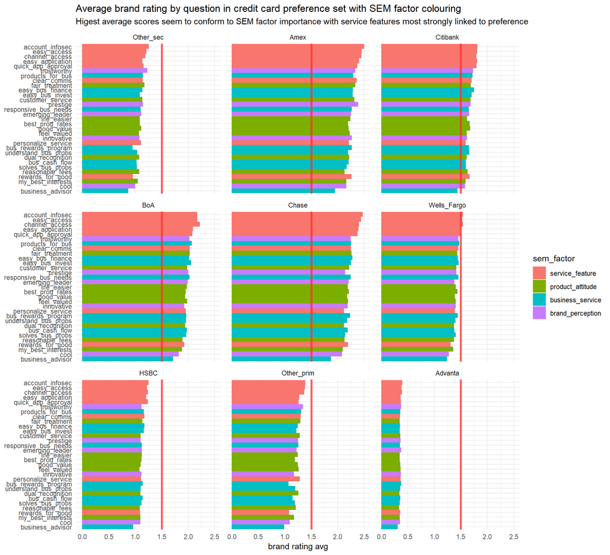

```r
SF <- c("easy_access", "channel_access", "personalize_service", "rewards_for_good",
        "easy_application", "clear_comms", "account_infosec",
        "quick_app_approval")

BP <- c("cool", "emerging_leader", "innovative", "prestige", "trustworthy")

PA <- c("customer_service", "best_prod_rates", "dual_recognition", "my_best_interests",
        "feel_valued", "life_easier", "reasonable_fees", "fair_treatment", "good_value")

BS <- c("products_for_bus", "bus_cash_flow", "responsive_bus_needs", "business_advisor",
        "understand_bus_probs", "solves_bus_probs", "bus_rewards_program",
        "easy_bus_finance", "easy_bus_invest")

cc_brands %>%
  select(3, 8:38) %>%
  group_by(brand) %>%
  summarise_if(is.numeric, function(x) mean(x)) %>%
  gather(key = "variable", value = "value", -brand) %>%
  mutate(brand = factor(brand, levels = c("Other_sec", "Amex", "Citibank", "BoA",
                                          "Chase", "Wells_Fargo", "HSBC",
                                          "Other_prim", "Advanta")),
         sem_factor = case_when(
           variable %in% SF ~ "service_feature",
           variable %in% BP ~ "brand_perception",
           variable %in% PA ~ "product_attitude",
           variable %in% BS ~ "business_service"
             )
        ) %>%
  mutate(sem_factor = factor(sem_factor, levels = c("service_feature",
                                                    "product_attitude",
                                                    "business_service",
                                                    "brand_perception")),
         variable = reorder(variable, value)) %>%
  filter(value != 4) %>%
  ggplot(aes(variable, value, colour = sem_factor, fill = sem_factor)) +
  geom_col() +
  geom_hline(yintercept = 1.5, colour = "firebrick1", size = 1.3, alpha = .75) +
  coord_flip() +
  facet_wrap(facets = "brand") +
  labs(title = "Average brand rating by question in credit card preference set with SEM factor colouring",
       subtitle = "Higest average scores seem to conform to SEM factor importance with service features most strongly linked to preference",
       x = NULL,
       y = "brand rating avg")
```

The results seem to indicate that product positioning should lean on how the brand’s service features might help a consumer. Introducing campaigns around these features seems like a good choice for underperforming brands Outside of the immediate marketing implications, this result would be useful for shaping business operations as well given the features are tangible services offered by a firm. Overall, this work cold help refine both product positioning and operational services.

### References

#### 1. Rose Hartman: “CFA in Lavaan”, http://www.understandingdata.net/2017/03/22/cfa-in-lavaan/

#### 2. “Fit Statistics Commonly Reported for CFA and SEM”, https://www.cscu.cornell.edu/news/Handouts/SEM_fit.pdf